# **Panorama da inflação**

Os principais índices de inflação do Brasil, apontam em junho de 2001 um avanço da inflação de em média **0.70%**. Com esse resultado, no ano a inflação acumula uma variação média positiva de **3.49%**, e em 12 meses uma variação média acumulada de **8.87%**.

|  | Variação mensal | Variação acumulada no ano | Variação acumulada em 12 meses |
| --- | --- | --- | --- |
| IPCA | 0.52% | 2.96% | 7.35% |
| INPC | 0.6% | 3.81% | 8.06% |
| IGP-M | 0.98% | 3.69% | 11.19% |
| IGP-DI | 1.46% | 4.23% | 11.49% |
| IPA | 1.96% | 0.05% | 0.14% |
| IPC | 0.52% | 2.77% | 7.46% |
| INCC | 1.16% | 4.31% | 7.39% |

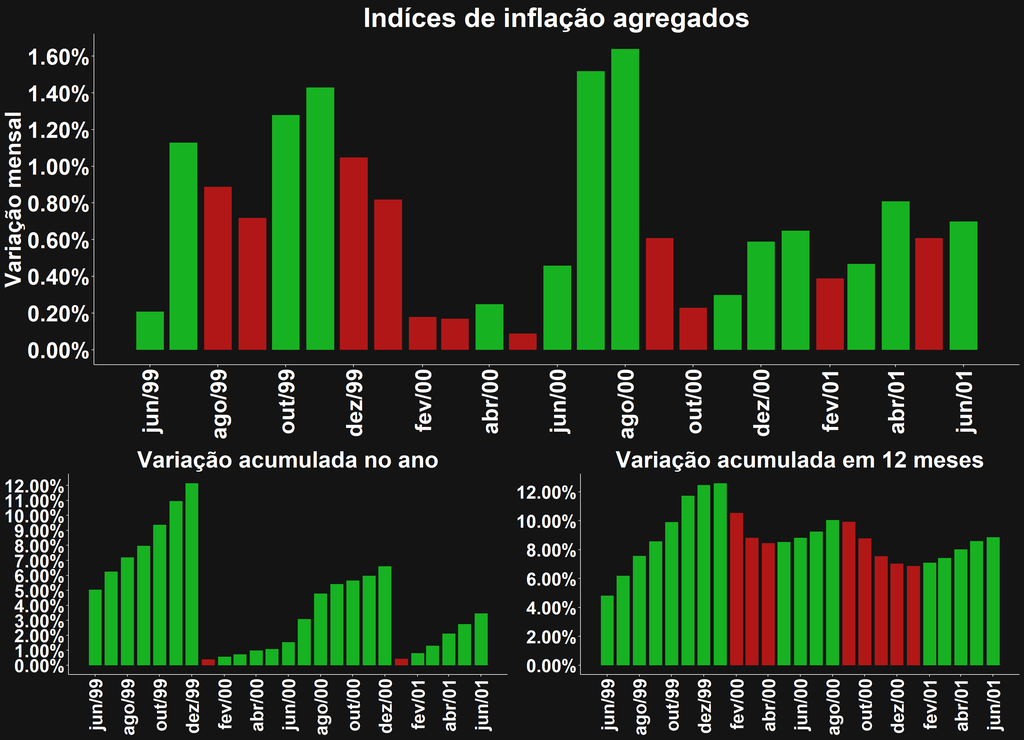

Índices selecionados para a média: IPCA, INPC e IGP-M.

# IPCA

O Indíce de Preços ao Consumidor Amplo (IPCA) variou 0.52% em junho, valor superior ao mesmo período do ano anterior quando apresentou uma taxa de 0.23%. Com esse resultado o indíce acumula no ano uma variação positiva de 2.96%, e em 12 meses uma variação positiva de 7.35%.

|  | 06/2000 | 05/2001 | 06/2001 |
| --- | --- | --- | --- |
| Variação mensal | 0.23% | 0.41% | 0.52% |
| Variação acumulada no ano | 1.64% | 2.42% | 2.96% |
| Variação acumulada em 12 meses | 6.51% | 7.04% | 7.35% |

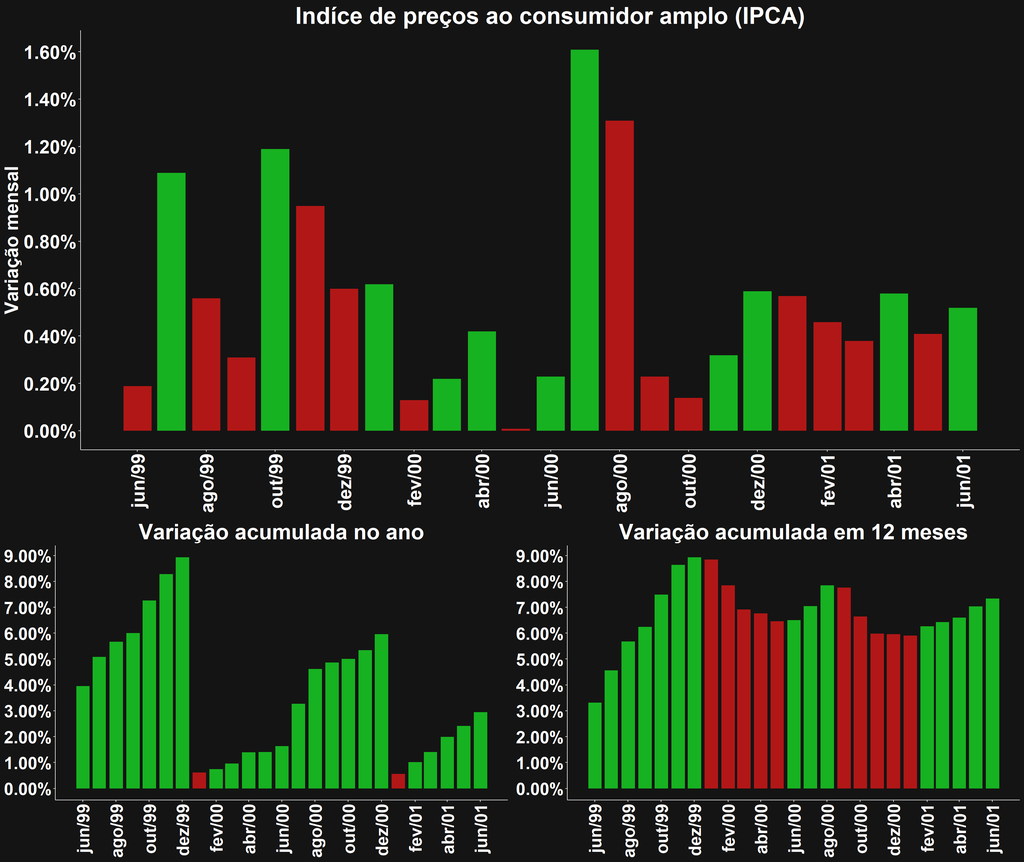

|  | Variação mensal | Variação acumulada no ano | Peso mensal |
| --- | --- | --- | --- |
| Alimentação e bebidas | 0.1% | 4.4% | 22.41% |
| Habitação | 1.02% | 3.96% | 15.87% |
| Artigos de residência | 0.04% | 0.75% | 5.75% |
| Vestuário | 1.04% | 0.03% | 5.34% |
| Transportes | 1.34% | 2.96% | 21.84% |
| Saúde e cuidados pessoais | -0.64% | 0.99% | 10.9% |
| Despesas pessoais | 0.08% | 2.18% | 9.53% |
| Educação | 0.14% | 5.73% | 4.94% |
| Comunicação | 1.17% | 1.76% | 3.43% |

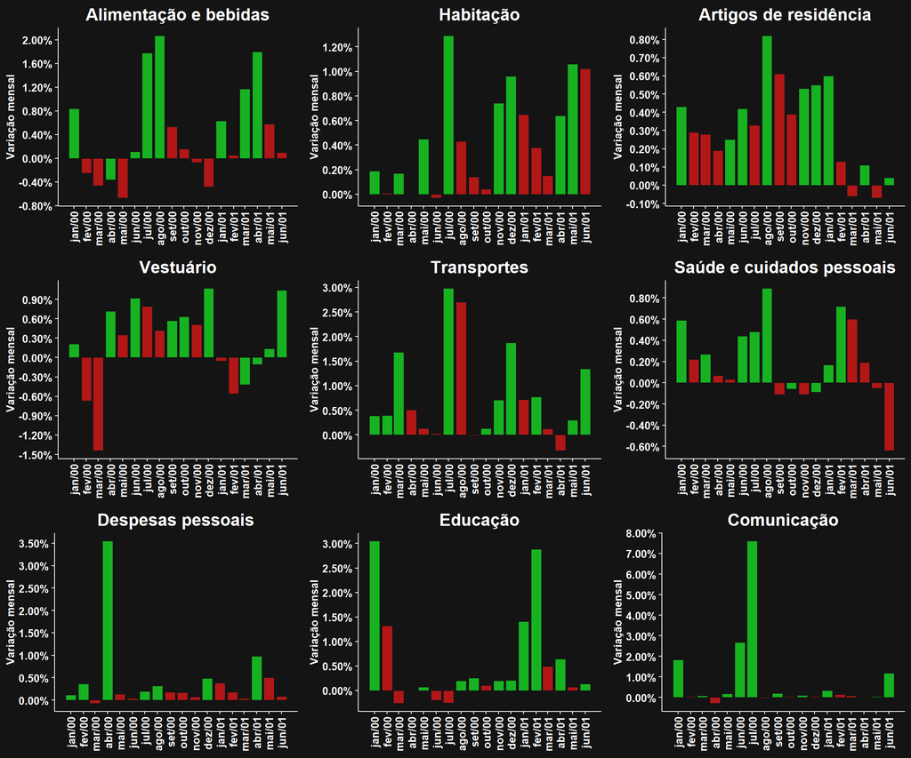

A nível de sub-itens os que mais influenciaram positivamente no resultado em relação ao seu peso foram Ônibus urbano (5.22%%) e Taxa de água e esgoto (4.48%%), e negativamente Anti-inflamatório e antirreumático (-4.93%%) e Hipotensor e hipocolesterolêmico (-3.54%%).

|  | Variação mensal | Variação acumulada no ano | Peso mensal |
| --- | --- | --- | --- |
| Ônibus urbano | 5.22% | 11.27% | 4.46% |
| Taxa de água e esgoto | 4.48% | 10.77% | 1.59% |
| Passagem aérea | 10.37% | 7.51% | 0.37% |
| Telefone fixo | 1.34% | 1.82% | 2.95% |

|  | Variação mensal | Variação acumulada no ano | Peso mensal |
| --- | --- | --- | --- |
| Hipotensor e hipocolesterolêmico | -3.54% | 0.29% | 0.8% |
| Anti-infeccioso e antibiótico | -4.05% | -0.92% | 0.49% |
| Anti-inflamatório e antirreumático | -4.93% | -4.75% | 0.63% |
| Batata-inglesa | -9.52% | 33.21% | 0.22% |

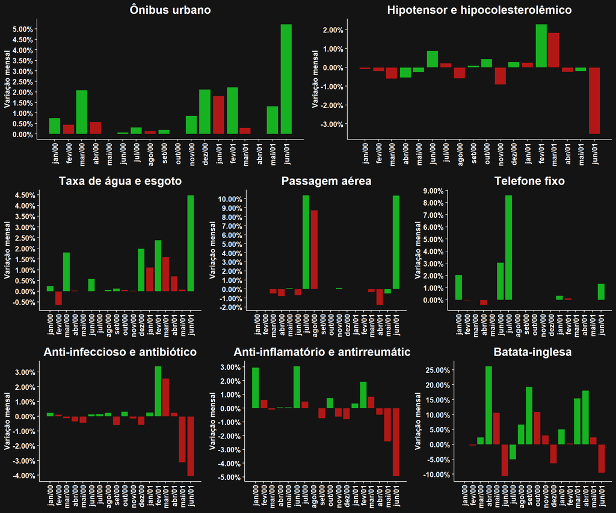

# INPC

O Indíce Nacional de Preços ao Consumidor (INPC) variou 0.6% em junho, valor superior ao mesmo período do ano anterior quando apresentou uma taxa de 0.3%. Com esse resultado o indíce acumula no ano uma variação positiva de 3.81%, e em 12 meses uma variação positiva de 8.06%.

|  | 06/2000 | 05/2001 | 06/2001 |
| --- | --- | --- | --- |
| Variação mensal | 0.3% | 0.57% | 0.6% |
| Variação acumulada no ano | 1.13% | 3.19% | 3.81% |
| Variação acumulada em 12 meses | 5.58% | 7.73% | 8.06% |

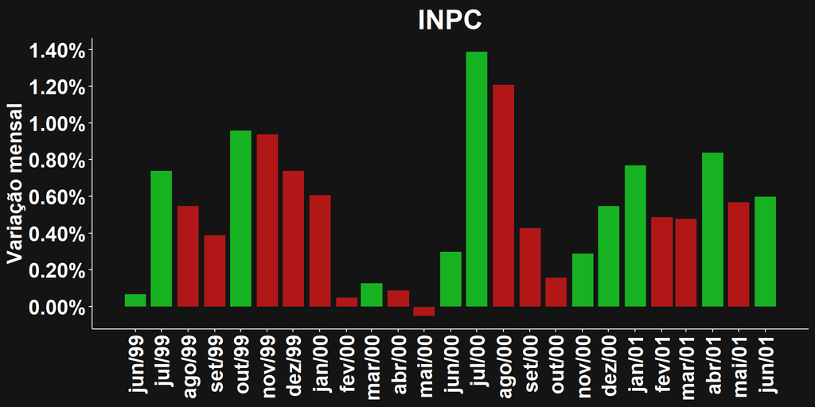

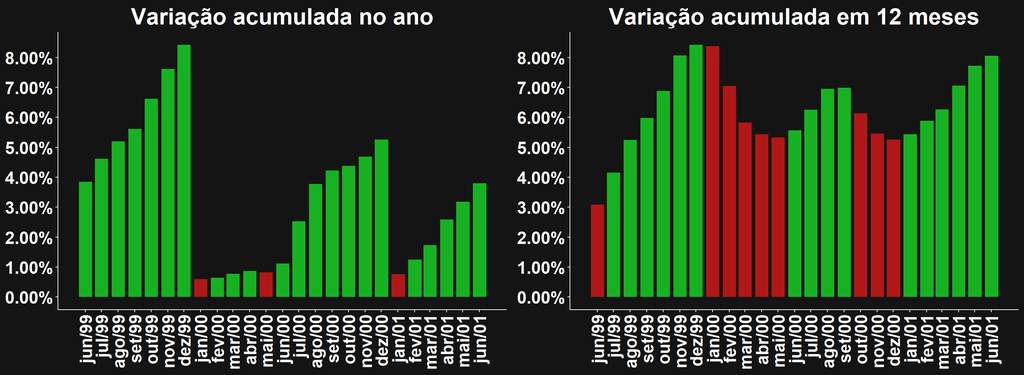

# IGP-M

O Indíce Geral de Preços de Mercado (IGP-M) variou 0.98% em junho, valor superior ao mesmo período do ano anterior quando apresentou uma taxa de 0.85%. Com esse resultado o indíce acumula no ano uma variação positiva de 3.69%, e em 12 meses uma variação positiva de 11.19%.

|  | 06/2000 | 05/2001 | 06/2001 |
| --- | --- | --- | --- |
| Variação mensal | 0.85% | 0.86% | 0.98% |
| Variação acumulada no ano | 1.91% | 2.68% | 3.69% |
| Variação acumulada em 12 meses | 14.43% | 11.05% | 11.19% |

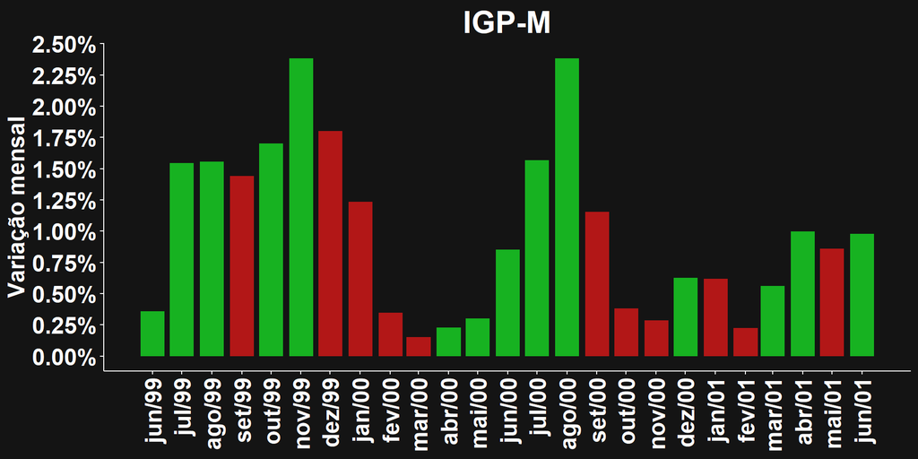

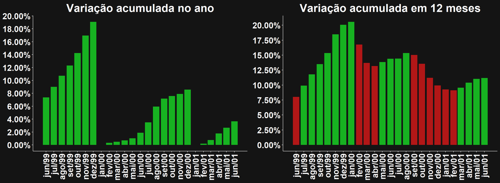

# IGP-DI

O Indíce Geral de Preços - Disponibilidade Interna (IGP-DI) variou 1.46% em junho, valor superior ao mesmo período do ano anterior quando apresentou uma taxa de 0.93%. Com esse resultado o indíce acumula no ano uma variação positiva de 4.23%, e em 12 meses uma variação positiva de 11.49%.

|  | 06/2000 | 05/2001 | 06/2001 |
| --- | --- | --- | --- |
| Variação mensal | 0.93% | 0.44% | 1.46% |
| Variação acumulada no ano | 2.12% | 2.73% | 4.23% |
| Variação acumulada em 12 meses | 14.1% | 10.9% | 11.49% |

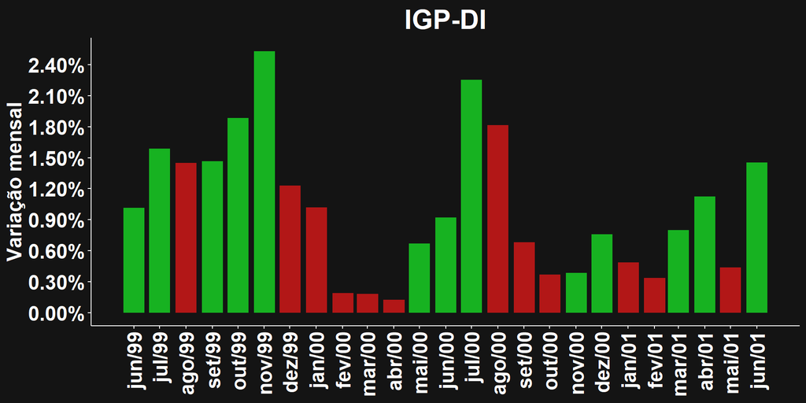

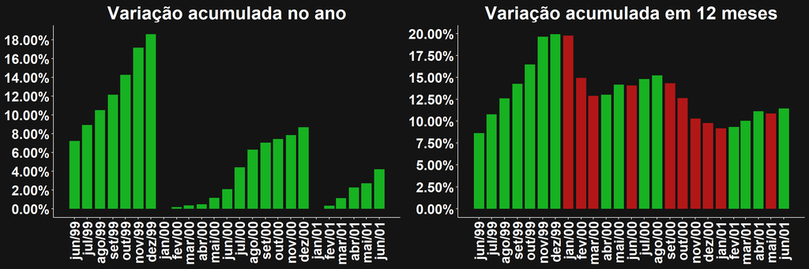

|  | 06/2000 | 05/2001 | 06/2001 |
| --- | --- | --- | --- |
| Variação mensal | 1.45% | 0.18% | 1.96% |
| Variação acumulada no ano | 0.03% | 0.03% | 0.05% |
| Variação acumulada em 12 meses | 0.19% | 0.14% | 0.14% |

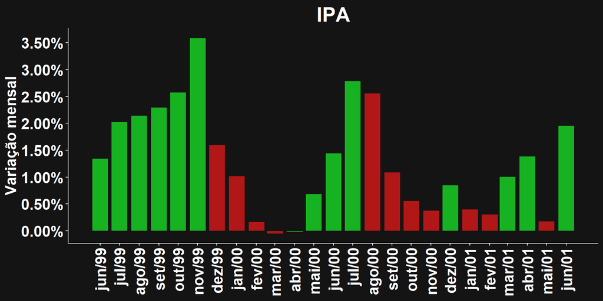

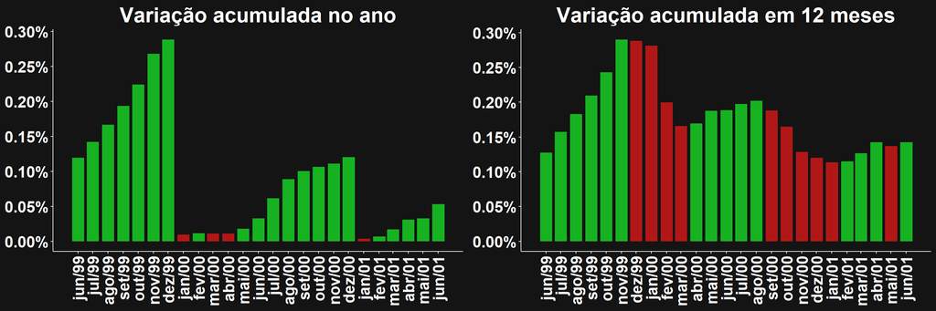

O Indíce de Preços ao Consumidor (IPC), integrante do IGP-DI com peso de 30%, apresentou variação de 0.52% em junho, valor superior ao mesmo período do ano anterior quando apresentou uma taxa de -0.01%. Com esse resultado o indíce acumula no ano uma variação positiva de 2.77%, e em 12 meses uma variação positiva de 7.46%.

|  | 06/2000 | 05/2001 | 06/2001 |
| --- | --- | --- | --- |
| Variação mensal | -0.01% | 0.4% | 0.52% |
| Variação acumulada no ano | 1.2% | 2.24% | 2.77% |
| Variação acumulada em 12 meses | 6.92% | 6.89% | 7.46% |

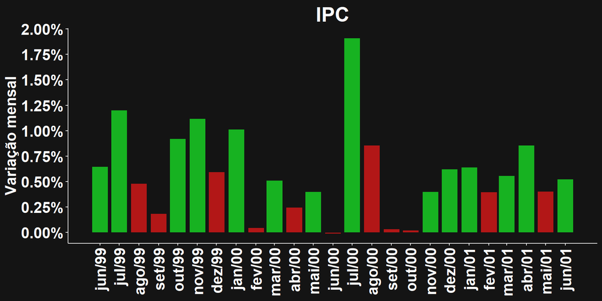

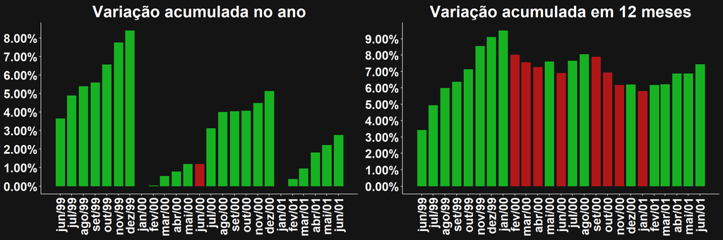

O Indíce Nacional de Custos de Construção (INCC), integrante do IGP-DI com peso de 10%, apresentou variação de 1.16% em junho, valor superior ao mesmo período do ano anterior quando apresentou uma taxa de 0.73%. Com esse resultado o indíce acumula no ano uma variação positiva de 4.31%, e em 12 meses uma variação positiva de 7.39%.

|  | 06/2000 | 05/2001 | 06/2001 |
| --- | --- | --- | --- |
| Variação mensal | 0.73% | 2.11% | 1.16% |
| Variação acumulada no ano | 4.07% | 3.12% | 4.31% |
| Variação acumulada em 12 meses | 10.53% | 6.93% | 7.39% |

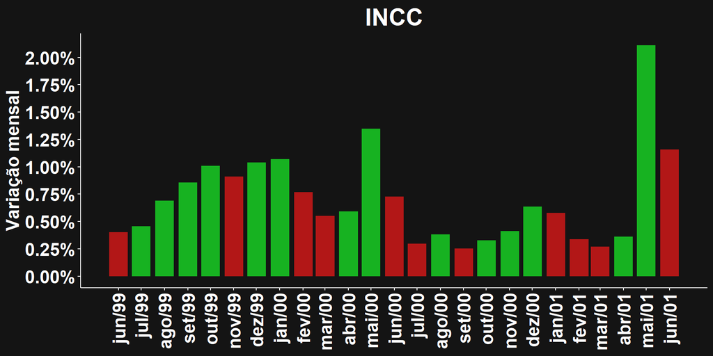

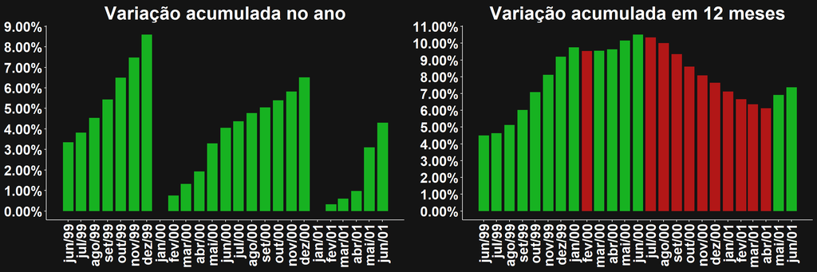

# Estatísticas

As estatísticas descritivas a seguir são feitas com base nos últimos 48 meses, e tem como objetivo possibilitar a avaliação do resultado observado em comparação aos períodos anteriores.

|  | Minimo | 1 Quartil | Mediana | Media | 3 Quartil | Maximo | Desvio Padrão |
| --- | --- | --- | --- | --- | --- | --- | --- |
| IPCA | -0.51% | 0.18% | 0.36% | 0.42% | 0.58% | 1.61% | 0.41% |
| INPC | -0.49% | 0.12% | 0.46% | 0.43% | 0.67% | 1.39% | 0.42% |
| IGP-M | -0.32% | 0.19% | 0.52% | 0.76% | 1.04% | 3.61% | 0.83% |
| IGP-DI | -0.38% | 0.17% | 0.63% | 0.76% | 1.13% | 4.44% | 0.89% |
| IPA | -0.82% | 0.04% | 0.72% | 0.98% | 1.58% | 6.99% | 1.36% |
| IPC | -0.52% | 0.12% | 0.41% | 0.45% | 0.64% | 1.91% | 0.47% |
| INCC | -0.5% | 0.29% | 0.51% | 0.56% | 0.86% | 2.11% | 0.44% |

Levando em consideração o desvio padrão de cada indíce, proporcionalmente os que mais se afastaram da média foram o INCC, o IGP-DI e o IPA.

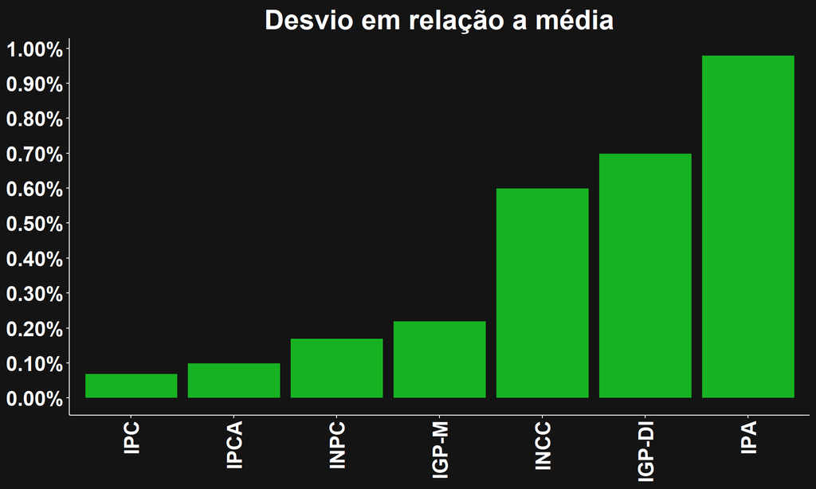

**João Victor Gomes**  
**jvg.santana@gmail.com**  
**[linkedin.com/in/jvictorgomes](https://www.linkedin.com/in/jvictorgomes/)**